# Ames - Tidymodels

Lilivette Cruz

2024-02-10

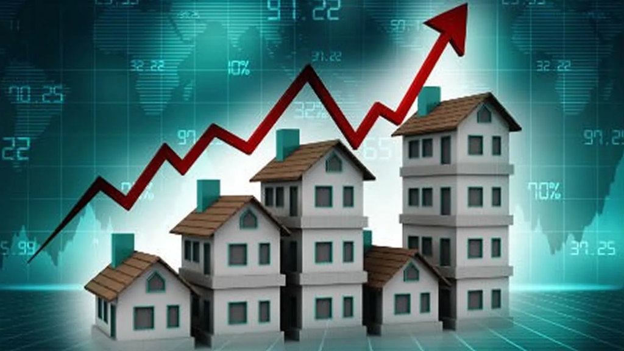

## Dataset content

The Ames Housing dataset contains information about residential properties in Ames, Iowa, USA. It is often used in regression modeling tasks, particularly for predicting house prices.

### Variables description

- **MSSubClass**: Identifies the type of dwelling involved in the sale.
- **MSZoning**: Identifies the general zoning classification of the sale.
- **LotFrontage**: Linear feet of street connected to property.
- **LotArea**: Lot size in square feet.
- **Street**: Type of road access to property.
- **Alley**: Type of alley access to property.
- **LotShape**: General shape of property.
- **LandContour**: Flatness of the property.
- **Utilities**: Type of utilities available.
- **LotConfig**: Lot configuration.
- **LandSlope**: Slope of property.
- **Neighborhood**: Physical locations within Ames city limits.
- **Condition1**: Proximity to various conditions.
- **Condition2**: Proximity to various conditions (if more than one is present).
- **BldgType**: Type of dwelling.
- **HouseStyle**: Style of dwelling.
- **OverallQual**: Overall material and finish quality of the house.
- **OverallCond**: Overall condition rating of the house.
- **YearBuilt**: Original construction date.
- **YearRemodAdd**: Remodel date (same as construction date if no remodeling or additions).
- **RoofStyle**: Type of roof.
- **RoofMatl**: Roof material.
- **Exterior1st**: Exterior covering on house.
- **Exterior2nd**: Exterior covering on house (if more than one material).
- **MasVnrType**: Masonry veneer type.
- **MasVnrArea**: Masonry veneer area in square feet.
- **ExterQual**: Exterior material quality.
- **ExterCond**: Present condition of the material on the exterior.
- **Foundation**: Type of foundation.
- **BsmtQual**: Height of the basement.
- **BsmtCond**: General condition of the basement.
- **BsmtExposure**: Walkout or garden level basement walls.
- **BsmtFinType1**: Quality of basement finished area.
- **BsmtFinSF1**: Type 1 finished square feet.
- **BsmtFinType2**: Quality of second finished area (if present).
- **BsmtFinSF2**: Type 2 finished square feet.
- **BsmtUnfSF**: Unfinished square feet of basement area.
- **TotalBsmtSF**: Total square feet of basement area.
- **Heating**: Type of heating.
- **HeatingQC**: Heating quality and condition.
- **CentralAir**: Central air conditioning.
- **Electrical**: Electrical system.
- **1stFlrSF**: First Floor square feet.
- **2ndFlrSF**: Second floor square feet.
- **LowQualFinSF**: Low quality finished square feet (all floors).
- **GrLivArea**: Above grade (ground) living area square feet.
- **BsmtFullBath**: Basement full bathrooms.
- **BsmtHalfBath**: Basement half bathrooms.
- **FullBath**: Full bathrooms above grade.
- **HalfBath**: Half baths above grade.
- **Bedroom**: Number of bedrooms above basement level.
- **Kitchen**: Number of kitchens.
- **KitchenQual**: Kitchen quality.
- **TotRmsAbvGrd**: Total rooms above grade (does not include bathrooms).
- **Functional**: Home functionality rating.
- **Fireplaces**: Number of fireplaces.
- **FireplaceQu**: Fireplace quality.
- **GarageType**: Garage location.
- **GarageYrBlt**: Year garage was built.
- **GarageFinish**: Interior finish of the garage.
- **GarageCars**: Size of garage in car capacity.
- **GarageArea**: Size of garage in square feet.
- **GarageQual**: Garage quality.
- **GarageCond**: Garage condition.
- **PavedDrive**: Paved driveway.
- **WoodDeckSF**: Wood deck area in square feet.
- **OpenPorchSF**: Open porch area in square feet.
- **EnclosedPorch**: Enclosed porch area in square feet.
- **3SsnPorch**: Three season porch area in square feet.
- **ScreenPorch**: Screen porch area in square feet.
- **PoolArea**: Pool area in square feet.
- **PoolQC**: Pool quality.
- **Fence**: Fence quality.
- **MiscFeature**: Miscellaneous feature not covered in other categories.
- **MiscVal**: $Value of miscellaneous feature.
- **MoSold**: Month Sold (MM).
- **YrSold**: Year Sold (YYYY).
- **SaleType**: Type of sale.
- **SaleCondition**: Condition of sale.

## Exploration

### Dataset load and initial preview

```r
data(ames)
head(ames)
```

```
## # A tibble: 6 × 74
##   MS_SubClass             MS_Zoning Lot_Frontage Lot_Area Street Alley Lot_Shape
##   <fct>                   <fct>            <dbl>    <int> <fct>  <fct> <fct>
## 1 One_Story_1946_and_New… Resident…          141    31770 Pave   No_A… Slightly…
## 2 One_Story_1946_and_New… Resident…           80    11622 Pave   No_A… Regular
## 3 One_Story_1946_and_New… Resident…           81    14267 Pave   No_A… Slightly…
## 4 One_Story_1946_and_New… Resident…           93    11160 Pave   No_A… Regular
## 5 Two_Story_1946_and_New… Resident…           74    13830 Pave   No_A… Slightly…
## 6 Two_Story_1946_and_New… Resident…           78     9978 Pave   No_A… Slightly…
## # ℹ 67 more variables: Land_Contour <fct>, Utilities <fct>, Lot_Config <fct>,
## #   Land_Slope <fct>, Neighborhood <fct>, Condition_1 <fct>, Condition_2 <fct>,
## #   Bldg_Type <fct>, House_Style <fct>, Overall_Cond <fct>, Year_Built <int>,
## #   Year_Remod_Add <int>, Roof_Style <fct>, Roof_Matl <fct>,
## #   Exterior_1st <fct>, Exterior_2nd <fct>, Mas_Vnr_Type <fct>,
## #   Mas_Vnr_Area <dbl>, Exter_Cond <fct>, Foundation <fct>, Bsmt_Cond <fct>,
## #   Bsmt_Exposure <fct>, BsmtFin_Type_1 <fct>, BsmtFin_SF_1 <dbl>, …
```

```r
nrow(ames)
```

```
## [1] 2930
```

```r
ncol(ames)
```

```
## [1] 74
```

```r
colnames(ames)
```

```
##  [1] "MS_SubClass"        "MS_Zoning"          "Lot_Frontage"
##  [4] "Lot_Area"           "Street"             "Alley"
##  [7] "Lot_Shape"          "Land_Contour"       "Utilities"
## [10] "Lot_Config"         "Land_Slope"         "Neighborhood"
## [13] "Condition_1"        "Condition_2"        "Bldg_Type"
## [16] "House_Style"        "Overall_Cond"       "Year_Built"
## [19] "Year_Remod_Add"     "Roof_Style"         "Roof_Matl"
## [22] "Exterior_1st"       "Exterior_2nd"       "Mas_Vnr_Type"
## [25] "Mas_Vnr_Area"       "Exter_Cond"         "Foundation"
## [28] "Bsmt_Cond"          "Bsmt_Exposure"      "BsmtFin_Type_1"
## [31] "BsmtFin_SF_1"       "BsmtFin_Type_2"     "BsmtFin_SF_2"
## [34] "Bsmt_Unf_SF"        "Total_Bsmt_SF"      "Heating"
## [37] "Heating_QC"         "Central_Air"        "Electrical"
## [40] "First_Flr_SF"       "Second_Flr_SF"      "Gr_Liv_Area"
## [43] "Bsmt_Full_Bath"     "Bsmt_Half_Bath"     "Full_Bath"
## [46] "Half_Bath"          "Bedroom_AbvGr"      "Kitchen_AbvGr"
## [49] "TotRms_AbvGrd"      "Functional"         "Fireplaces"
## [52] "Garage_Type"        "Garage_Finish"      "Garage_Cars"
## [55] "Garage_Area"        "Garage_Cond"        "Paved_Drive"
## [58] "Wood_Deck_SF"       "Open_Porch_SF"      "Enclosed_Porch"
## [61] "Three_season_porch" "Screen_Porch"       "Pool_Area"
## [64] "Pool_QC"            "Fence"              "Misc_Feature"
## [67] "Misc_Val"           "Mo_Sold"            "Year_Sold"
## [70] "Sale_Type"          "Sale_Condition"     "Sale_Price"
## [73] "Longitude"          "Latitude"
```

```r
summary(ames)
```

```
##                                MS_SubClass
##  One_Story_1946_and_Newer_All_Styles :1079
##  Two_Story_1946_and_Newer            : 575
##  One_and_Half_Story_Finished_All_Ages: 287
##  One_Story_PUD_1946_and_Newer        : 192
##  One_Story_1945_and_Older            : 139
##  Two_Story_PUD_1946_and_Newer        : 129
##  (Other)                             : 529
##                         MS_Zoning     Lot_Frontage       Lot_Area
##  Floating_Village_Residential: 139   Min.   :  0.00   Min.   :  1300
##  Residential_High_Density    :  27   1st Qu.: 43.00   1st Qu.:  7440
##  Residential_Low_Density     :2273   Median : 63.00   Median :  9436
##  Residential_Medium_Density  : 462   Mean   : 57.65   Mean   : 10148
##  A_agr                       :   2   3rd Qu.: 78.00   3rd Qu.: 11555
##  C_all                       :  25   Max.   :313.00   Max.   :215245
##  I_all                       :   2
##   Street                 Alley                     Lot_Shape    Land_Contour
##  Grvl:  12   Gravel         : 120   Regular             :1859   Bnk: 117
##  Pave:2918   No_Alley_Access:2732   Slightly_Irregular  : 979   HLS: 120
##              Paved          :  78   Moderately_Irregular:  76   Low:  60
##                                     Irregular           :  16   Lvl:2633
##
##
##
##   Utilities      Lot_Config   Land_Slope             Neighborhood
##  AllPub:2927   Corner : 511   Gtl:2789   North_Ames        : 443
##  NoSeWa:   1   CulDSac: 180   Mod: 125   College_Creek     : 267
##  NoSewr:   2   FR2    :  85   Sev:  16   Old_Town          : 239
##                FR3    :  14              Edwards           : 194
##                Inside :2140              Somerset          : 182
##                                          Northridge_Heights: 166
##                                          (Other)           :1439
##   Condition_1    Condition_2      Bldg_Type              House_Style
##  Norm   :2522   Norm   :2900   OneFam  :2425   One_Story       :1481
##  Feedr  : 164   Feedr  :  13   TwoFmCon:  62   Two_Story       : 873
##  Artery :  92   Artery :   5   Duplex  : 109   One_and_Half_Fin: 314
##  RRAn   :  50   PosA   :   4   Twnhs   : 101   SLvl            : 128
##  PosN   :  39   PosN   :   4   TwnhsE  : 233   SFoyer          :  83
##  RRAe   :  28   RRNn   :   2                   Two_and_Half_Unf:  24
##  (Other):  35   (Other):   2                   (Other)         :  27
```

[output cut: 97 more lines]

```
##  Min.   :    0.00   Min.   : 1.000   Min.   :2006   WD     :2536
##  1st Qu.:    0.00   1st Qu.: 4.000   1st Qu.:2007   New    : 239
##  Median :    0.00   Median : 6.000   Median :2008   COD    :  87
##  Mean   :   50.63   Mean   : 6.216   Mean   :2008   ConLD  :  26
##  3rd Qu.:    0.00   3rd Qu.: 8.000   3rd Qu.:2009   CWD    :  12
##  Max.   :17000.00   Max.   :12.000   Max.   :2010   ConLI  :   9
##                                                     (Other):  21
##  Sale_Condition   Sale_Price       Longitude         Latitude
##  Abnorml: 190   Min.   : 12789   Min.   :-93.69   Min.   :41.99
##  AdjLand:  12   1st Qu.:129500   1st Qu.:-93.66   1st Qu.:42.02
##  Alloca :  24   Median :160000   Median :-93.64   Median :42.03
##  Family :  46   Mean   :180796   Mean   :-93.64   Mean   :42.03
##  Normal :2413   3rd Qu.:213500   3rd Qu.:-93.62   3rd Qu.:42.05
##  Partial: 245   Max.   :755000   Max.   :-93.58   Max.   :42.06
##
```

## Data partitioning

```r
#Split train/Test
data <- ames
#Using the current time (in milliseconds or seconds) as a seed.
set.seed(as.numeric(format(Sys.time(), "%OS3")))

tic("Data Splitting") # Start timer for data splitting
split_inicial <- initial_split(data= data,
              prop= 0.8, #training proportion
              strata = Sale_Price #target variable
              )
data_train <- training(split_inicial)
data_test <- testing(split_inicial)
toc() # End timer for data splitting
```

```
## Data Splitting: 0.05 sec elapsed
```

```r
summary(data_train$Sale_Price)
```

```
##    Min. 1st Qu.  Median    Mean 3rd Qu.    Max.
##   12789  129500  160000  180051  213500  755000
```

```r
summary(data_test$Sale_Price)
```

```
##    Min. 1st Qu.  Median    Mean 3rd Qu.    Max.
##   37900  129425  160250  183763  213438  625000
```

## Data Pre-processing

```r
#Recipes

#Set Transformations
#recipe()
transformer <- recipe(formula= Sale_Price ~.,
       data=data_train) %>%
      step_naomit(all_predictors()) %>%
      step_nzv (all_predictors()) %>%
      step_center(all_numeric(),-all_outcomes()) %>%
      step_scale(all_numeric(),-all_outcomes()) %>%
      step_dummy(all_nominal(),-all_outcomes())

transformer
```

```
## ── Recipe ──────────────────────────────────────────────────────────────────────
```

```
## ── Inputs
```

```
## Number of variables by role
```

```
## outcome:    1
## predictor: 73
```

```
## ── Operations
```

```
## • Removing rows with NA values in: all_predictors()
```

```
## • Sparse, unbalanced variable filter on: all_predictors()
```

```
## • Centering for: all_numeric(), -all_outcomes()
```

```
## • Scaling for: all_numeric(), -all_outcomes()
```

```
## • Dummy variables from: all_nominal(), -all_outcomes()
```

```r
#Training recipe
#prep()
tic("Data Preprocessing") # Start timer for data preprocessing

transformer_fit <- prep(transformer)

#Apply transformations to datasets
#bake()

data_train_prep <- bake(transformer_fit,new_data = data_train)
data_test_prep <- bake(transformer_fit,new_data = data_test)
toc() # End timer for data preprocessing
```

```
## Data Preprocessing: 0.46 sec elapsed
```

```r
head(data_train_prep)
```

```
## # A tibble: 6 × 214
##   Lot_Frontage Lot_Area Year_Built Year_Remod_Add Mas_Vnr_Area BsmtFin_SF_1
##          <dbl>    <dbl>      <dbl>          <dbl>        <dbl>        <dbl>
## 1        0.663   0.204    -0.334           -1.11        -0.564        0.796
## 2        0.363   0.0559   -0.00544         -0.630       -0.564       -1.44
## 3       -1.11   -1.11     -0.00544         -0.630        2.27         0.796
## 4       -1.11   -1.11     -0.00544         -0.630        2.20         0.796
## 5       -1.11   -1.11     -0.00544         -0.630        1.58         1.24
## 6       -0.147  -0.795     0.192           -0.344       -0.564       -1.44
## # ℹ 208 more variables: Bsmt_Unf_SF <dbl>, Total_Bsmt_SF <dbl>,
## #   First_Flr_SF <dbl>, Second_Flr_SF <dbl>, Gr_Liv_Area <dbl>,
## #   Bsmt_Full_Bath <dbl>, Bsmt_Half_Bath <dbl>, Full_Bath <dbl>,
## #   Half_Bath <dbl>, Bedroom_AbvGr <dbl>, TotRms_AbvGrd <dbl>,
## #   Fireplaces <dbl>, Garage_Cars <dbl>, Garage_Area <dbl>, Wood_Deck_SF <dbl>,
## #   Open_Porch_SF <dbl>, Mo_Sold <dbl>, Year_Sold <dbl>, Longitude <dbl>,
## #   Latitude <dbl>, Sale_Price <int>, …
```

## Regression Model

Create a price prediction regression model

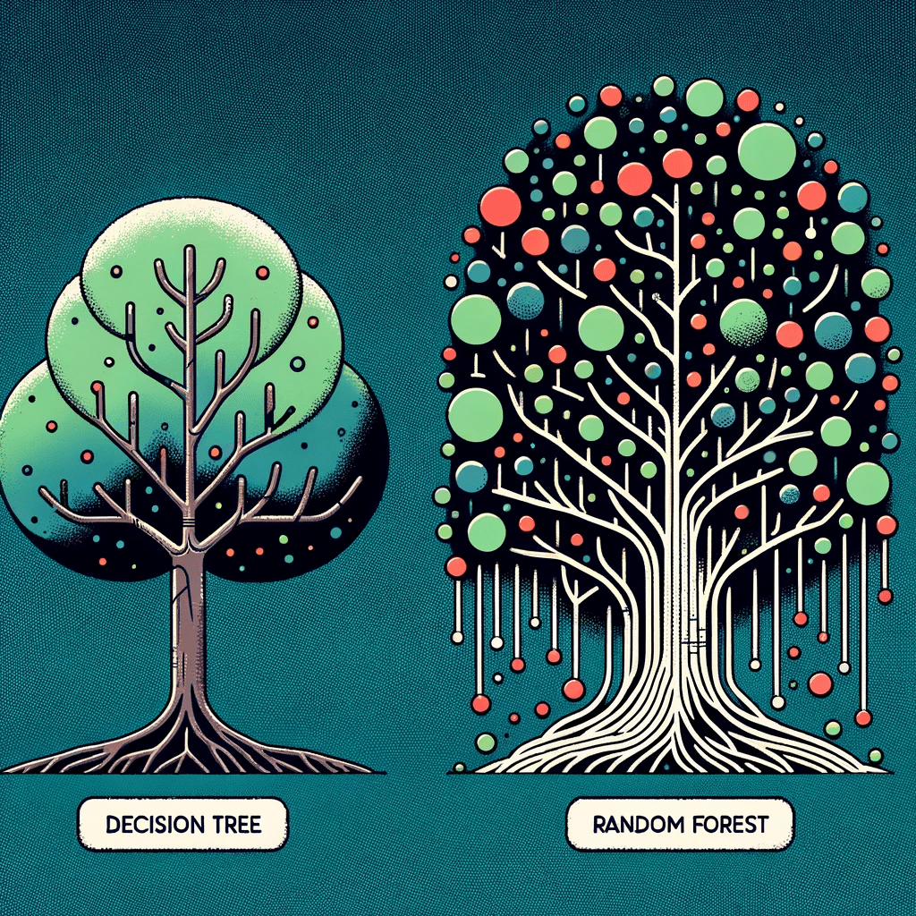

### Decision Tree

Training with hyperparameter optimization and cross-validation

```r
#Choose model
model_tree <- decision_tree(mode = "regression",
              tree_depth = tune(),
              min_n = tune()) %>%
      set_engine(engine = "rpart") #paqueteria

#Cross Validation
tic("Cross Validation") # Start timer for cross validation
cv_folds <- vfold_cv(data = data_train,
         v = 5, #numero de particiones
         strata = Sale_Price #variable objetivo
         )
toc() # End timer for cross validation
```

```
## Cross Validation: 0.02 sec elapsed
```

```r
# Hyperparameter optimization

#Random Grid
hiperpar_grid_1 <-  grid_random(
  tree_depth(range = c(1,10),trans = NULL),
  min_n( range = c(2,50),trans = NULL ),
  size = 100
)
head(hiperpar_grid_1)
```

```
## # A tibble: 6 × 2
##   tree_depth min_n
##        <int> <int>
## 1          6    10
## 2          6    18
## 3          8     7
## 4          1    34
## 5          7    22
## 6          5    10
```

```r
#Grid search
hiperpar_grid_2 <- grid_regular(
  tree_depth(range = c(1,10),trans = NULL),
  min_n( range = c(2,50),trans = NULL ),
  levels = c(10,49)
)
head(hiperpar_grid_2)
```

```
## # A tibble: 6 × 2
##   tree_depth min_n
##        <int> <int>
## 1          1     2
## 2          2     2
## 3          3     2
## 4          4     2
## 5          5     2
## 6          6     2
```

```r
#Grid search
hiperpar_grid_3 <- grid_regular(
  tree_depth(range = c(1,10),trans = NULL),
  min_n( range = c(2,50),trans = NULL ),
  levels = c(10,10)
)
head(hiperpar_grid_3)
```

```
## # A tibble: 6 × 2
##   tree_depth min_n
##        <int> <int>
## 1          1     2
## 2          2     2
## 3          3     2
## 4          4     2
## 5          5     2
## 6          6     2
```

```r
#Optimization
tic("Hyperparameter Optimization") # Start timer for hyperparameter optimization

grid_fit <- tune_grid(
  object = model_tree,
  #Pre procesamiento de los datos
  #Recipe
  preprocessor = transformer,
  #Resample que se crearon sin preprocesar
  resamples = cv_folds,
  #Metricas evaluacion
  metrics = metric_set(rmse,mae),
  control = control_grid(save_pred = TRUE),
  grid = hiperpar_grid_3
)
toc() # End timer for hyperparameter optimization
```

```
## Hyperparameter Optimization: 187.66 sec elapsed
```

Measure execution times for comparison, using the tictoc package in R.

Evaluation of training error (through visualizations)

```r
grid_fit
```

```
## # Tuning results
## # 5-fold cross-validation using stratification
## # A tibble: 5 × 5
##   splits             id    .metrics           .notes           .predictions
##   <list>             <chr> <list>             <list>           <list>
## 1 <split [1872/470]> Fold1 <tibble [200 × 6]> <tibble [0 × 3]> <tibble>
## 2 <split [1873/469]> Fold2 <tibble [200 × 6]> <tibble [0 × 3]> <tibble>
## 3 <split [1874/468]> Fold3 <tibble [200 × 6]> <tibble [0 × 3]> <tibble>
## 4 <split [1874/468]> Fold4 <tibble [200 × 6]> <tibble [0 × 3]> <tibble>
## 5 <split [1875/467]> Fold5 <tibble [200 × 6]> <tibble [0 × 3]> <tibble>
```

```r
grid_fit %>% unnest(.metrics)
```

```
## # A tibble: 1,000 × 10
##    splits             id    tree_depth min_n .metric .estimator .estimate
##    <list>             <chr>      <int> <int> <chr>   <chr>          <dbl>
##  1 <split [1872/470]> Fold1          1     2 rmse    standard      61945.
##  2 <split [1872/470]> Fold1          1     2 mae     standard      46438.
##  3 <split [1872/470]> Fold1          2     2 rmse    standard      52102.
##  4 <split [1872/470]> Fold1          2     2 mae     standard      37373.
##  5 <split [1872/470]> Fold1          3     2 rmse    standard      45826.
##  6 <split [1872/470]> Fold1          3     2 mae     standard      33294.
##  7 <split [1872/470]> Fold1          4     2 rmse    standard      39472.
##  8 <split [1872/470]> Fold1          4     2 mae     standard      28671.
##  9 <split [1872/470]> Fold1          5     2 rmse    standard      39946.
## 10 <split [1872/470]> Fold1          5     2 mae     standard      28598.
## # ℹ 990 more rows
## # ℹ 3 more variables: .config <chr>, .notes <list>, .predictions <list>
```

```r
grid_fit %>% collect_metrics(summarize = TRUE)
```

```
## # A tibble: 200 × 8
##    tree_depth min_n .metric .estimator   mean     n std_err .config
##         <int> <int> <chr>   <chr>       <dbl> <int>   <dbl> <chr>
##  1          1     2 mae     standard   46121.     5    707. Preprocessor1_Model…
##  2          1     2 rmse    standard   62056.     5   1612. Preprocessor1_Model…
##  3          2     2 mae     standard   38634.     5    738. Preprocessor1_Model…
##  4          2     2 rmse    standard   54024.     5   1550. Preprocessor1_Model…
##  5          3     2 mae     standard   33868.     5    816. Preprocessor1_Model…
##  6          3     2 rmse    standard   48099.     5   2034. Preprocessor1_Model…
##  7          4     2 mae     standard   30212.     5   1113. Preprocessor1_Model…
##  8          4     2 rmse    standard   43504.     5   2336. Preprocessor1_Model…
##  9          5     2 mae     standard   29674.     5    889. Preprocessor1_Model…
## 10          5     2 rmse    standard   42767.     5   1952. Preprocessor1_Model…
## # ℹ 190 more rows
```

```r
grid_fit %>% show_best(metric = "rmse",n=5)
```

```
## # A tibble: 5 × 8
##   tree_depth min_n .metric .estimator   mean     n std_err .config
##        <int> <int> <chr>   <chr>       <dbl> <int>   <dbl> <chr>
## 1          5    50 rmse    standard   41817.     5   1853. Preprocessor1_Model0…
## 2          6    50 rmse    standard   41817.     5   1853. Preprocessor1_Model0…
## 3          7    50 rmse    standard   41817.     5   1853. Preprocessor1_Model0…
## 4          8    50 rmse    standard   41817.     5   1853. Preprocessor1_Model0…
## 5          9    50 rmse    standard   41817.     5   1853. Preprocessor1_Model0…
```

```r
grid_fit %>% show_best(metric = "mae",n=5)
```

```
## # A tibble: 5 × 8
##   tree_depth min_n .metric .estimator   mean     n std_err .config
##        <int> <int> <chr>   <chr>       <dbl> <int>   <dbl> <chr>
## 1          5    50 mae     standard   29349.     5    784. Preprocessor1_Model0…
## 2          6    50 mae     standard   29349.     5    784. Preprocessor1_Model0…
## 3          7    50 mae     standard   29349.     5    784. Preprocessor1_Model0…
## 4          8    50 mae     standard   29349.     5    784. Preprocessor1_Model0…
## 5          9    50 mae     standard   29349.     5    784. Preprocessor1_Model0…
```

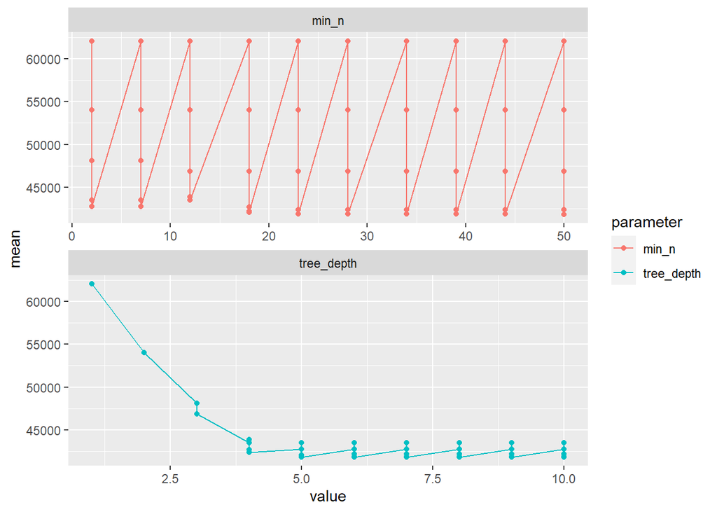

```r
#Evolucion del error

#Hiperparametros por separado
grid_fit %>% collect_metrics(summarize = TRUE) %>%
  filter(.metric=="rmse") %>%
  pivot_longer(cols = c(tree_depth,min_n),
               values_to = "value",
               names_to = "parameter") %>%
  ggplot(aes(x=value,y=mean,color=parameter)) +
  geom_point() + geom_line() +
  facet_wrap(facets = vars(parameter),nrow=2,scales = "free")
```

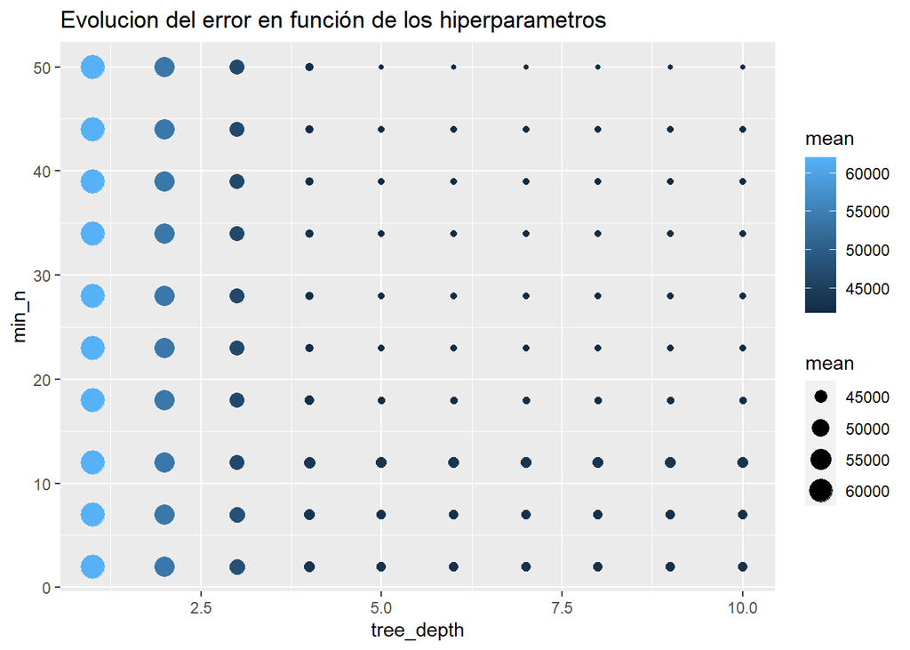

```r
#Hiperparametros en conjunto
grid_fit %>% collect_metrics(summarize = TRUE) %>%
  filter(.metric=="rmse") %>%
  ggplot(aes(x=tree_depth,y=min_n,color=mean,size=mean)) +
  geom_point() +
  ggtitle("Evolucion del error en función de los hiperparametros")
```

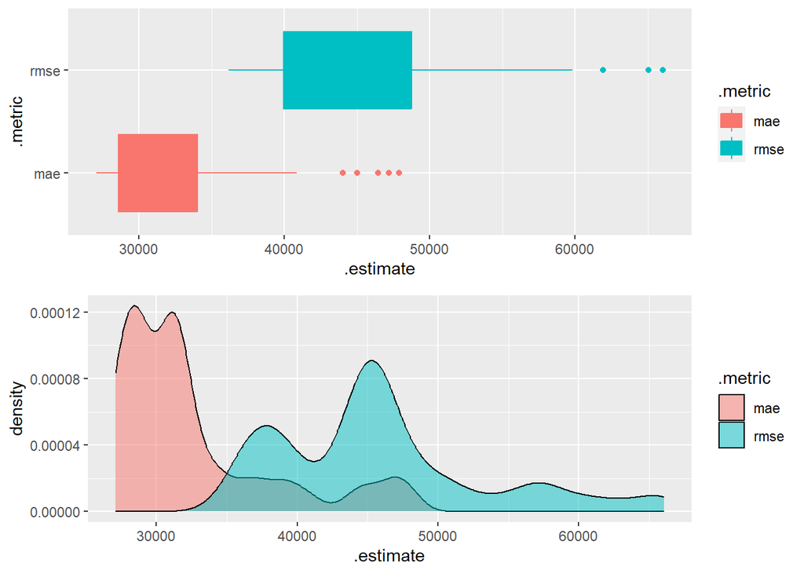

```r
p1 <- grid_fit %>% collect_metrics(summarize = FALSE) %>%
  ggplot(aes(x=.metric,y=.estimate,fill=.metric,color=.metric)) +
  geom_boxplot() +
  coord_flip()

p2 <-  grid_fit %>% collect_metrics(summarize = FALSE) %>%
  ggplot(aes(x=.estimate,fill=.metric)) +
  geom_density(alpha=0.5)

ggarrange(p1,p2,nrow=2)
```

Final model

```r
#Choose the best model

best_hip <- select_best(grid_fit,metric="rmse")

final_model_tree <- finalize_model(x=model_tree,
                                   parameters = best_hip )

final_model_tree
```

```
## Decision Tree Model Specification (regression)
##
## Main Arguments:
##   tree_depth = 5
##   min_n = 50
##
## Computational engine: rpart
```

```r
final_model_tree_fit <- final_model_tree %>%
  fit(formula = Sale_Price ~.,
      data = data_train_prep)
```

Validation with test data

```r
predicciones <- final_model_tree_fit %>%
  predict(new_data = data_test_prep,
          type = "numeric")

predicciones %>%  head()
```

```
## # A tibble: 6 × 1
##     .pred
##     <dbl>
## 1 168048.
## 2 327466.
## 3 127230.
## 4 168048.
## 5 256152.
## 6 256152.
```

```r
predicciones <- predicciones %>% bind_cols(data_test_prep %>% select(Sale_Price))

rmse(predicciones,truth = Sale_Price, estimate= .pred)
```

```
## # A tibble: 1 × 3
##   .metric .estimator .estimate
##   <chr>   <chr>          <dbl>
## 1 rmse    standard      40343.
```

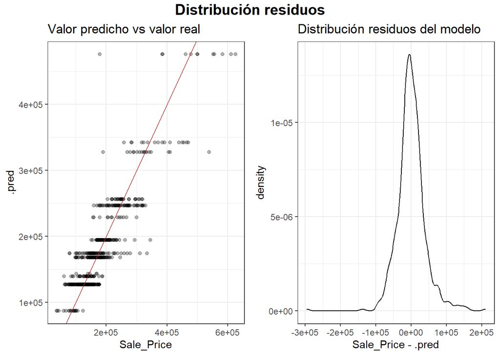

```r
#Plot prediction & residuals

p1 <- predicciones %>%  ggplot(
  aes(x = Sale_Price, y = .pred)
) +
  geom_point(alpha = 0.3) +
  geom_abline(slope = 1, intercept = 0, color = "firebrick") +
  labs(title = "Valor predicho vs valor real") +
  theme_bw()

p2 <- predicciones %>% ggplot(
  aes(x = Sale_Price - .pred)
) +
  geom_density() +
  labs(title = "Distribución residuos del modelo") +
  theme_bw()

ggarrange(plotlist = list(p1, p2)) %>%
  annotate_figure(
    top = text_grob("Distribución residuos", size = 15, face = "bold")
  )
```